# MATH1005 Project1

Statistical Report of COVID-19, Pneumonia, and Influenza Death Counts in the United States

SID: 490185362 & 500483091 & 450192993

University of Sydney | MATH1005 | February Intensive 2021

# 1 Executive Summary

The aim of this report is to assess the data of COVID-19, Pneumonia, and Influenza deaths counts in the United States across all ages and sexes in order to evaluate the spread of COVID-19 compared to Pneumonia and Influenza between males and females, and to investigate which illness, out of COVID-19, Pneumonia, and Influenza has the greatest impact on total deaths within the United States. The analyses include diagnoses of the appropriateness of the statistical models used for the data.

The first discovery is that there is a greater discrepancy in death counts for COVID-19 between males and females (across all ages) than for Pneumonia and Influenza. Moreover, there was an approximately equal range for males with COVID-19 and Pneumonia. There was a greater range for males with Pneumonia and the greatest range was for females with COVID-19. Influenza showed much lower results for both males and females compared to COVID-19 and Pneumonia.

The second discovery is that COVID-19 showed the greatest impact on total deaths within the US, closely followed by Pneumonia, with Influenza showing a far less impact on total death counts. These results have implications for the impact that an effective and wide-spread vaccine can have on saving lives.

# 2 Full Report

## 2.1 Initial Data Analysis (IDA)

### 2.1.1 Source of Data

```r
data = read.csv("Provisional_COVID-19_Death_Counts_by_Sex__Age__and_State.csv",
                na.strings = c("0","-9"), header = TRUE)
Table= read.csv("Table_of_variables.csv", header = TRUE)
```

### 2.1.2 Complexity of Data

```r
head(data, n=3 )  #Returns the first three rows of the data
```

```
##   Data.as.of Start.Date   End.Date         State       Sex    Age.group
## 1 01/13/2021 01/01/2020 01/09/2021 United States All Sexes     All Ages
## 2 01/13/2021 01/01/2020 01/09/2021 United States All Sexes Under 1 year
## 3 01/13/2021 01/01/2020 01/09/2021 United States All Sexes   0-17 years
##   COVID.19.Deaths Total.Deaths Pneumonia.Deaths Pneumonia.and.COVID.19.Deaths
## 1          329593      3247306           319102                        152620
## 2              34        18083              192                             6
## 3             157        31847              529                            28
##   Influenza.Deaths Pneumonia..Influenza..or.COVID.19.Deaths Footnote
## 1             8696                                   503675
## 2               21                                      241
## 3              175                                      833
```

```r
dim(data)  #Returns the dimension of data as rows and columns
```

```
## [1] 2661   13
```

```r
class(data) #Represent the type or style of data
```

```
## [1] "data.frame"
```

```r
names(data)  #Returns the names of columns or variables
```

```
##  [1] "Data.as.of"
##  [2] "Start.Date"
##  [3] "End.Date"
##  [4] "State"
##  [5] "Sex"
##  [6] "Age.group"
##  [7] "COVID.19.Deaths"
##  [8] "Total.Deaths"
##  [9] "Pneumonia.Deaths"
## [10] "Pneumonia.and.COVID.19.Deaths"
## [11] "Influenza.Deaths"
## [12] "Pneumonia..Influenza..or.COVID.19.Deaths"
## [13] "Footnote"
```

```r
data$Data.as.of=as.factor(data$Data.as.of)  #Changing all the character arguments to factors
data$Start.Date=as.factor(data$Start.Date)
data$End.Date=as.factor(data$End.Date)
data$State=as.factor(data$State)
data$Sex=as.factor(data$Sex)
data$Age.group=as.factor(data$Age.group)
str(data) #Retruns the internal structure of the data
```

```
## 'data.frame':    2661 obs. of  13 variables:
##  $ Data.as.of                              : Factor w/ 1 level "01/13/2021": 1 1 1 1 1 1 1 1 1 1 ...
##  $ Start.Date                              : Factor w/ 1 level "01/01/2020": 1 1 1 1 1 1 1 1 1 1 ...
##  $ End.Date                                : Factor w/ 1 level "01/09/2021": 1 1 1 1 1 1 1 1 1 1 ...
##  $ State                                   : Factor w/ 54 levels "Alabama","Alaska",..: 47 47 47 47 47 47 47 47 47 47 ...
##  $ Sex                                     : Factor w/ 4 levels "All Sexes","Female",..: 1 1 1 1 1 1 1 1 1 1 ...
##  $ Age.group                               : Factor w/ 16 levels "0-17 years","1-4 years",..: 15 16 1 2 9 3 4 5 6 7 ...
##  $ COVID.19.Deaths                         : int  329593 34 157 21 55 510 1235 2196 13191 5742 ...
##  $ Total.Deaths                            : int  3247306 18083 31847 3329 5334 34251 60423 70231 211545 99685 ...
##  $ Pneumonia.Deaths                        : int  319102 192 529 117 151 697 1603 2519 12727 5664 ...
##  $ Pneumonia.and.COVID.19.Deaths           : int  152620 6 28 3 10 181 514 977 6065 2589 ...
##  $ Influenza.Deaths                        : int  8696 21 175 59 74 80 146 232 800 352 ...
##  $ Pneumonia..Influenza..or.COVID.19.Deaths: int  503675 241 833 194 270 1102 2460 3953 20567 9137 ...
##  $ Footnote                                : chr  "" "" "" "" ...
```

### 2.1.3 Classification of Variables

```r
library(formattable) #A table of the variables in the data with their description and classification
formattable(Table,
            align =c("l","l","c","c"),
            list(`Indicator Name` = formatter(
            "span", style = ~ style(color = "grey",font.weight = "bold"))))
```

| Variable | Description | R.Classification. | Changed.To |
| --- | --- | --- | --- |
| Data as of | Date of analysis | Character | Factor |
| Start date | First week of data collection period | Character | Factor |
| End date | Last week of data collection period | Character | Factor |
| State | Jurisdiction of occurrence | Character | Factor |
| Sex | Sex | Character | Factor |
| Age Group | Age group | Character | Factor |
| Covid-19 Deaths | Deaths including COVID-19 | Integer | Unchnaged |
| Total Deaths | Deaths from all causes of death | Integer | Unchnaged |
| Pneumonia Deaths | Pneumonia Deaths | Integer | Unchnaged |
| Pneumonia and Covid-19 Deaths | Deaths with Pneumonia and COVID-19 | Integer | Unchnaged |
| Influenza Deaths | Influenza deaths | Integer | Unchnaged |
| Pneumonia Influenza or Covid-19 Death | Deaths with Pneumonia, influenza or COVID-19 | Integer | Unchnaged |
| Footnotes | Notes | Character | Unchnaged |

### 2.1.4 Summary

The data is not valid/is limited because:

## 2.2 Research Question 1

How does the spread of COVID-19 death counts compare to Pneumonia and Influenza death counts in the United States? How does this compare between females and males?

### 2.2.1 Graphical summary

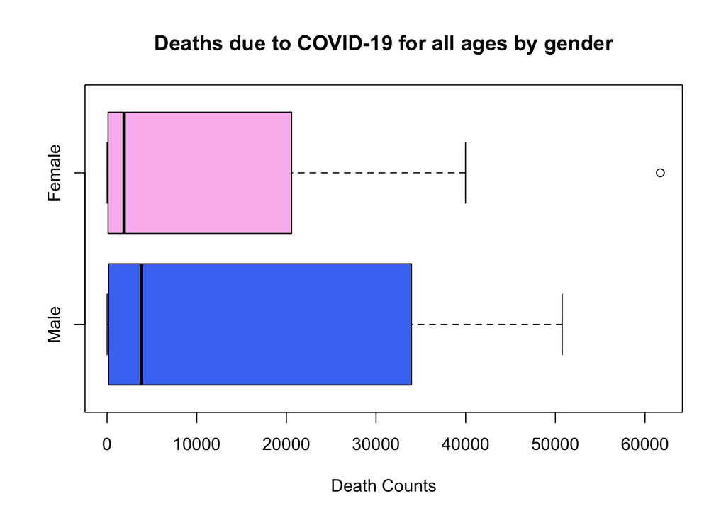

```r
covidUS <- data[c("State","Sex","Age.group","COVID.19.Deaths","Total.Deaths", "Pneumonia.Deaths","Influenza.Deaths")] # Creating subsets of the data
covidUS <- covidUS[!(covidUS$State!="United States"),]
covidUS <- covidUS[!(covidUS$Sex=="Unknown"),]
covidUS <- covidUS[!(covidUS$Age.group=="All Ages"),]
covidUS <- covidUS[!(covidUS$Age.group=="0-17 years"),]
covidUS <- covidUS[!(covidUS$Age.group=="18-29 years"),]
covidUS <- covidUS[!(covidUS$Age.group=="30-49 years"),]
covidUS <- covidUS[!(covidUS$Age.group=="50-64 years"),]
genders = c("Male","Female")

Fe_COVID = covidUS$COVID.19.Deaths[covidUS$Sex =="Female"]  # Deaths due to COVID-19
Ma_COVID = covidUS$COVID.19.Deaths[covidUS$Sex =="Male"]
Fe_Pneumonia = covidUS$Pneumonia.Deaths[covidUS$Sex =="Female"]  # Deaths due to Pneumonia
Ma_Pneumonia = covidUS$Pneumonia.Deaths[covidUS$Sex =="Male"]
Fe_Influenza = covidUS$Influenza.Deaths[covidUS$Sex =="Female"]  # Deaths due to Influenza
Ma_Influenza = covidUS$Influenza.Deaths[covidUS$Sex =="Male"]

#Box plot comparing  deaths counts due to COVID-19 between Female and Male
boxplot(Ma_COVID,Fe_COVID,names=genders,horizontal=TRUE,
        xlab ="Death Counts",col=c("#497AF4","#FABCEE"),main="Deaths due to COVID-19 for all ages by gender")
```

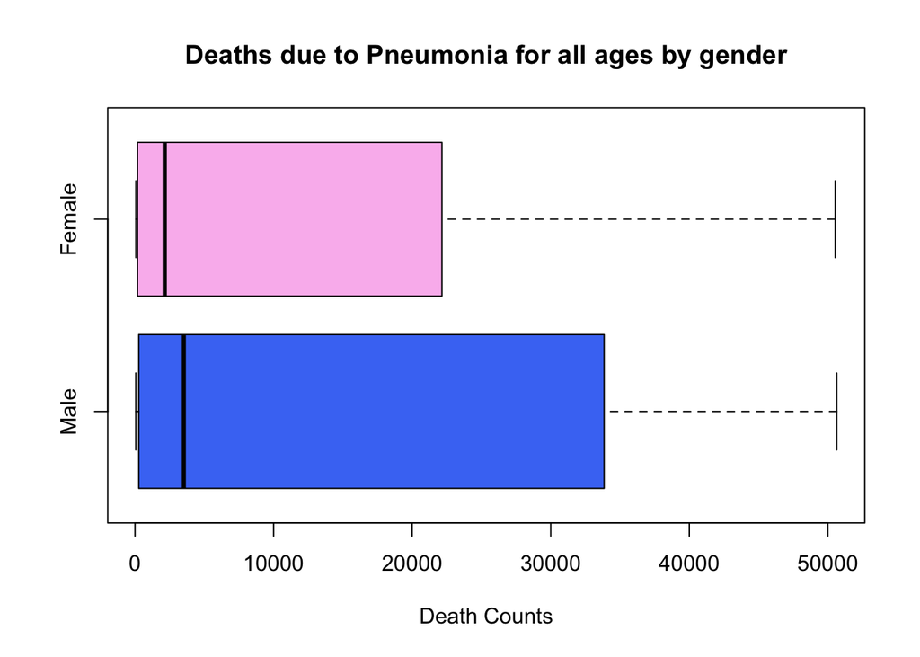

```r
#Box plot comparing  deaths counts due to Pneumonia between Female and Male
boxplot(Ma_Pneumonia,Fe_Pneumonia,names=genders,horizontal=TRUE,
        xlab ="Death Counts",col=c("#497AF4","#FABCEE"),main="Deaths due to Pneumonia for all ages by gender")
```

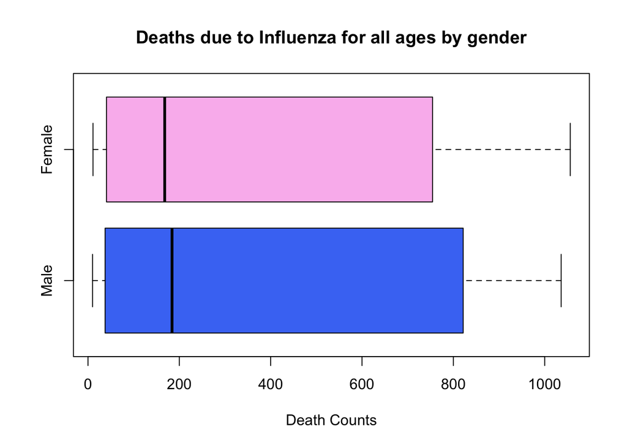

```r
#Box plot comparing  deaths counts due to Influenza between Female and Male
boxplot(Ma_Influenza,Fe_Influenza,names=genders,horizontal=TRUE,
        xlab ="Death Counts",col=c("#497AF4","#FABCEE"),main="Deaths due to Influenza for all ages by gender")
```

### 2.2.2 Numerical summary

```r
summary(covidUS)
```

```
##            State           Sex           Age.group  COVID.19.Deaths
##  United States:33   All Sexes:11   1-4 years  : 3   Min.   :     9
##  Alabama      : 0   Female   :11   15-24 years: 3   1st Qu.:    55
##  Alaska       : 0   Male     :11   25-34 years: 3   Median :  3839
##  Arizona      : 0   Unknown  : 0   35-44 years: 3   Mean   : 19975
##  Arkansas     : 0                  45-54 years: 3   3rd Qu.: 38830
##  California   : 0                  5-14 years : 3   Max.   :105673
##  (Other)      : 0                  (Other)    :15
##   Total.Deaths    Pneumonia.Deaths Influenza.Deaths
##  Min.   :  1399   Min.   :   55    Min.   :  10
##  1st Qu.:  9958   1st Qu.:  192    1st Qu.:  43
##  Median : 67972   Median : 3520    Median : 232
##  Mean   :196803   Mean   :19339    Mean   : 527
##  3rd Qu.:374671   3rd Qu.:38461    3rd Qu.: 919
##  Max.   :978289   Max.   :93682    Max.   :1873
##
```

```r
#COVID-19 Female median
median(Fe_COVID)
```

```
## [1] 1903
```

```r
#COVID-19 Female IQR
IQR(Fe_COVID)
```

```
## [1] 20470
```

```r
#COVID-19 Male median
median(Ma_COVID)
```

```
## [1] 3839
```

```r
#COVID-19 Male IQR
IQR(Ma_COVID)
```

```
## [1] 33777
```

```r
#Pneumonia Female median
median(Fe_Pneumonia)
```

```
## [1] 2144
```

```r
#Pneumonia Female IQR
IQR(Fe_Pneumonia)
```

```
## [1] 21973.5
```

```r
#Pneumonia Male median
median(Ma_Pneumonia)
```

```
## [1] 3520
```

```r
#Pneumonia Male IQR
IQR(Ma_Pneumonia)
```

```
## [1] 33585.5
```

```r
#Influenza Female Median
median(Fe_Influenza)
```

```
## [1] 168
```

```r
#Influenza Female IQR
IQR(Fe_Influenza)
```

```
## [1] 714
```

```r
#Influenza Male median
median(Ma_Influenza)
```

```
## [1] 184
```

```r
#Influenza Male IQR
IQR(Ma_Influenza)
```

```
## [1] 784
```

```r
##The median is the second 2nd quartile
#The lower thresholds : LT =  Q_1 − 1.5 IQR
LT_Fe_COVID =  111.5 - 1.5*(IQR(Fe_COVID))  # Deaths due to COVID-19
LT_Ma_COVID =  171  - 1.5*(IQR(Ma_COVID))
LT_Fe_Pneumonia =  176 - 1.5*(IQR(Fe_Pneumonia ))  # Deaths due to Pneumonia
LT_MA_Pneumonia =  268.5 - 1.5*(IQR(Ma_Pneumonia ))
LT_Fe_Influenza =  40.5 - 1.5*(IQR(Fe_Influenza))  # Deaths due to Influenza
LT_MA_Influenza =  37.5 - 1.5*(IQR(Ma_Influenza))
#The upper thresholds : UT = Q_3 + 1.5 IQR
UT_Fe_COVID =  20581.5 + 1.5*(IQR(Fe_COVID))  # Deaths due to COVID-19
UT_Ma_COVID =  33948 + 1.5*(IQR(Ma_COVID))
UT_Fe_Pneumonia =  22150 + 1.5*(IQR(Fe_Pneumonia ))  # Deaths due to Pneumonia
UT_MA_Pneumonia =  33854.0 + 1.5*(IQR(Ma_Pneumonia ))
UT_Fe_Influenza =  754.5 + 1.5*(IQR(Fe_Influenza))  # Deaths due to Influenza
UT_MA_Influenza =  821.5 + 1.5*(IQR(Ma_Influenza))
```

### 2.2.3 Analysis

Each graph indicates the death counts for COVID-19, Pneumonia or Influenza within various age groups for both males and females within the United States, including:

Under 1 year  
1-4 years  
5-14 years  
15-24 years  
25-34 years  
35-44 years  
45-54 years  
55-64 years  
65-74 years  
75-84 years  
85 years and over

#### 2.2.3.1 Data analysis

Median and interquartile range (IQR) were used in place of mean and standard deviation (SD), as our data is right-skewed.

**—COVID-19—**  
Female median: 1903  
Male median: 3839

Female IQR: 20470  
Male IQR: 33777

The lower female median indicates an overall lower death rate for females than males for COVID-19, as 50% of age groups have a death count lower than 1903.

The middle 50% (Q2 and Q3) of values is much more spread for males, displayed by the wider box length within the male box plot and higher IQR value.

For both boxes, the lowest two quartiles indicated the densest data, showing that the COVID-19 death count is relatively low for the majority of age groups.

The range of deaths for females (~60,000) is higher than males (~50,000), thanks to an outlier, possibly showing that older females are more likely to contract/die from COVID-19 than males. However, this is confounded by the higher life expectancy of females.

**—PNEUMONIA—**  
Female median: 2144  
Male median: 3520

Female IQR: 21973.5  
Male IQR: 33585.5

Pneumonia has a lower female median than male median, similar to COVID-19’s statistical implications. This is also true for the IQR. However, as shown on the box plots comparison, the total range for both males and females is ~50,000. Assuming this death count belongs to an older population (shown in the data), it can be deduced that for older age groups, the Pneumonia death counts between males and females are very similar, despite the lower median in females.

Female IQR: 714  
Male IQR: 784

The medians and IQR for males and females are almost equal with similar ranges. This could be attributed to the prevalence of the influenza vaccine, which subdues variations caused by age, gender and other factors, also explaining the low death count of ~1000, compared to +50,000 for COVID-19 and Pneumonia.

### 2.2.4 Summary:

COVID-19 indicates a greater discrepancy in death counts across ages between males and females than Pneumonia and Influenza within the US, with Influenza showing the lowest discrepancy.

COVID-19 and Pneumonia reflected an approximately equal but greater range for males in Pneumonia; however, COVID-19 reflected the greatest range (60,000) for females.

Influenza had much lower results for both sexes, which can be attributed to the presence of an effective vaccine.

The Influenza data can be used as a model for COVID-19 to demonstrate the effect a widely implemented vaccine has on a society.

## 2.3 Research Question 2

Which illness, out of COVID-19, Pneumonia, and Influenza, has the highest impact on total death counts in the US across all ages and sexes?

```r
#Remove scientific notation format
options(scipen=999)

#Variables
##Deaths due to COVID-19 (all ages & sexes)
COVID_19 = covidUS$COVID.19.Deaths

##Deaths due to Pneumonia (all ages & sexes)
Pneumonia = covidUS$Pneumonia.Deaths

##Deaths due to Influenza (all ages & sexes)
Influenza = covidUS$Influenza.Deaths

##Total Deaths (all ages & sexes)
Total_Deaths = covidUS$Total.Deaths
```

### 2.3.1 Correlation Coefficients

```r
#Total Deaths vs COVID-19
cor(COVID_19,Total_Deaths)
```

```
## [1] 0.9959647
```

```r
#Total Deaths vs Pneumonia
cor(Pneumonia,Total_Deaths)
```

```
## [1] 0.9904165
```

```r
#Total Deaths vs Influenza
cor(Influenza,Total_Deaths)
```

```
## [1] 0.9457233
```

### 2.3.2 Regression Line

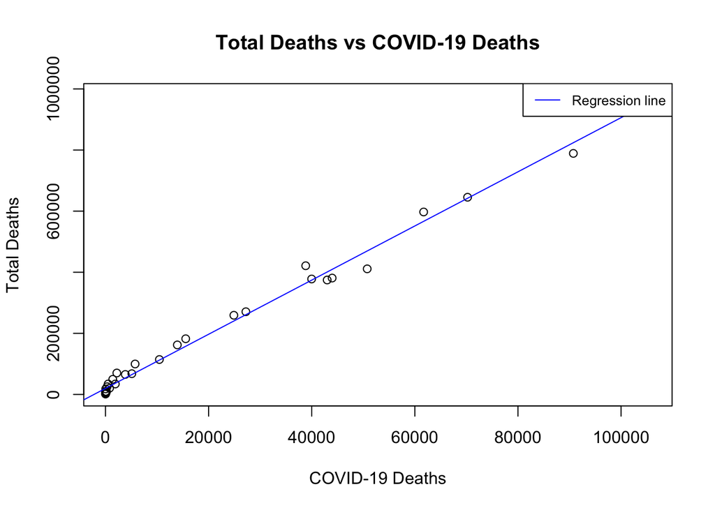

```r
#A regression line on the scatter plot for Total Deaths vs COVID 19
L_COVID_19 = lm(Total_Deaths~COVID_19)
plot(COVID_19,Total_Deaths,
     main = "Total Deaths vs COVID-19 Deaths",
     xlab = "COVID-19 Deaths",
     ylab = "Total Deaths")
abline(L_COVID_19,col="blue")
legend("topright",c("Regression line"),col ="blue",lty=1:2,cex=0.8)
```

```r
##Slope and Intercept
L_COVID_19$coeff
```

```
##  (Intercept)     COVID_19
## 19764.608100     8.862942
```

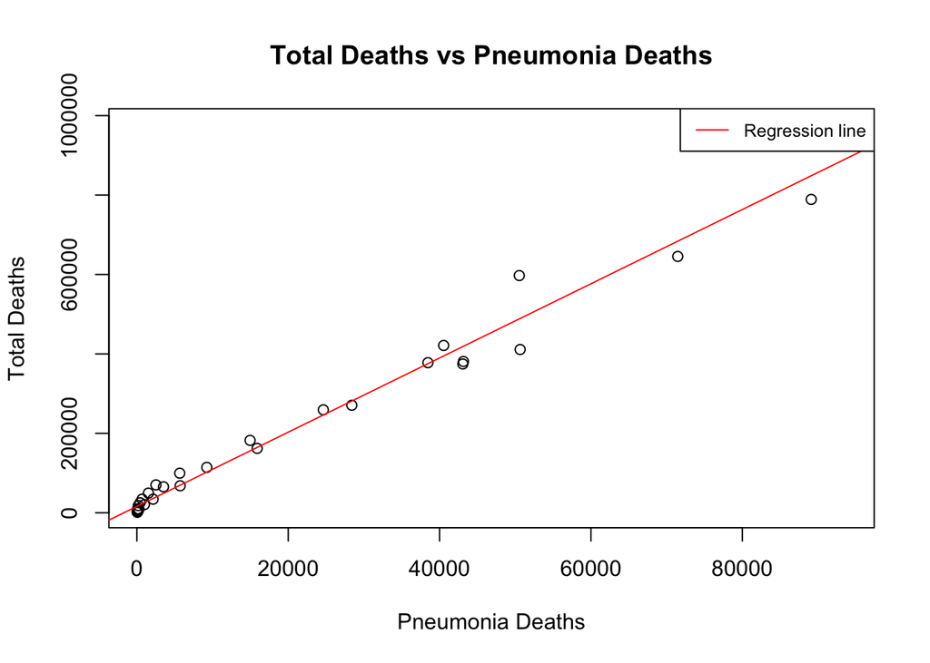

```r
#A regression line on the scatter plot for Total Deaths vs Pneumonia
L_Pneumonia = lm(Total_Deaths~Pneumonia)
plot(Pneumonia,Total_Deaths,
     main = "Total Deaths vs Pneumonia Deaths",
     xlab = "Pneumonia Deaths",
     ylab = "Total Deaths")
abline(L_Pneumonia,col="red")
legend("topright",c("Regression line"),col="red",lty=1:2,cex=0.8)
```

```r
##Slope and Intercept
L_Pneumonia$coeff
```

```
##  (Intercept)    Pneumonia
## 16069.767672     9.345382
```

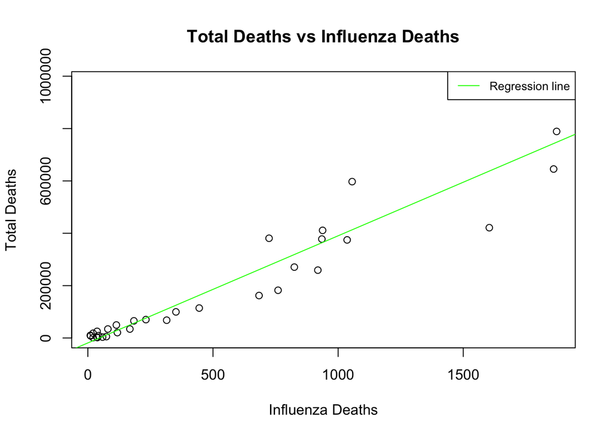

```r
#A regression line on the scatter plot for Total Deaths vs Influenza
L_Influenza = lm(Total_Deaths~Influenza)
plot(Influenza,Total_Deaths,
     main = "Total Deaths vs Influenza Deaths",
     xlab = "Influenza Deaths",
     ylab = "Total Deaths")
abline(L_Influenza,col="green")
legend("topright", c("Regression line"),col="green",lty=1:2,cex=0.8)
```

```r
##Slope and Intercept
L_Influenza$coeff
```

```
## (Intercept)   Influenza
## -18913.1180    409.3284
```

### 2.3.3 Residuals

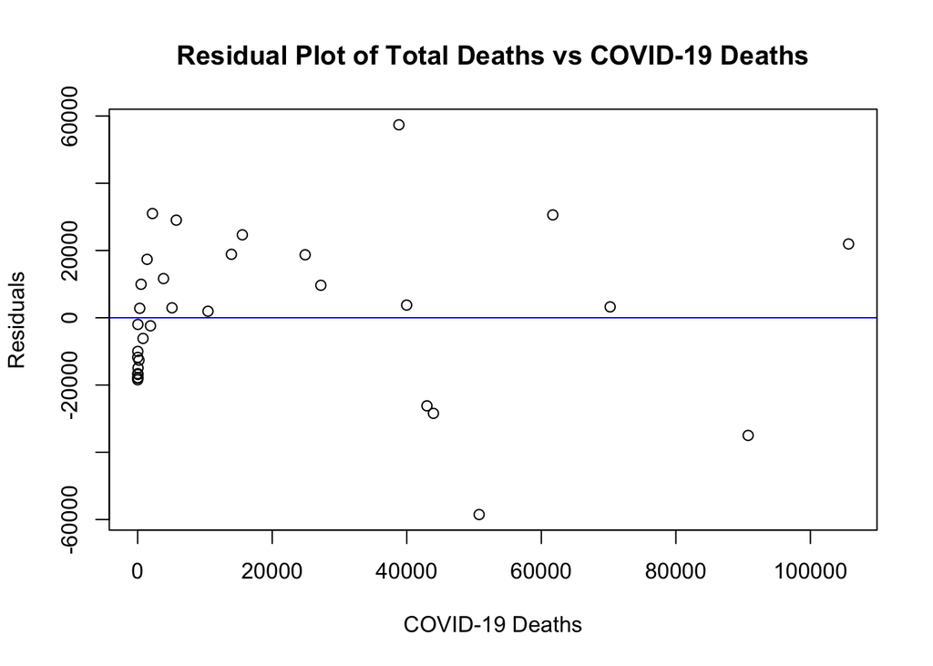

```r
#Residual plot for Total Deaths vs COVID 19
plot(COVID_19,L_COVID_19$residuals,xlab="COVID-19 Deaths",ylab ="Residuals", main="Residual Plot of Total Deaths vs COVID-19 Deaths")
abline(h=0,col="blue")
```

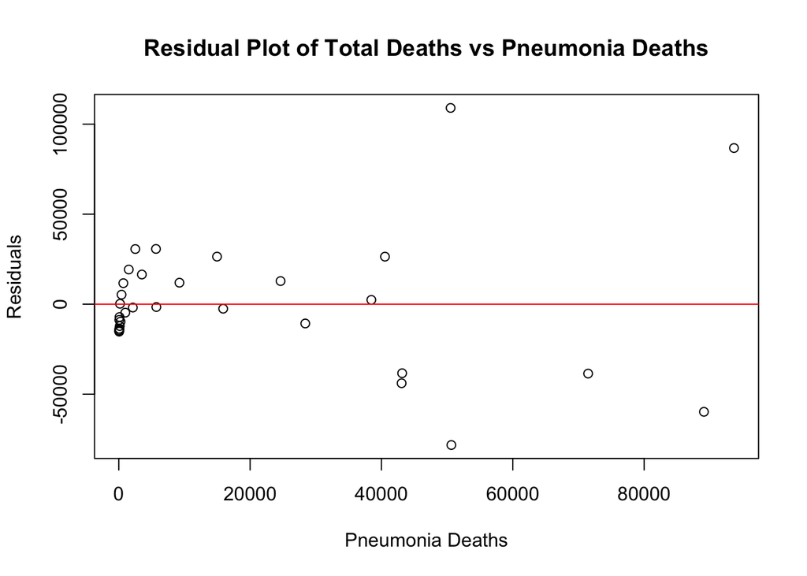

```r
#Residual plot for Total Deaths vs Pneumonia
plot(Pneumonia,L_Pneumonia$residuals,xlab="Pneumonia Deaths",ylab="Residuals",main="Residual Plot of Total Deaths vs Pneumonia Deaths")
abline(h=0,col="red")
```

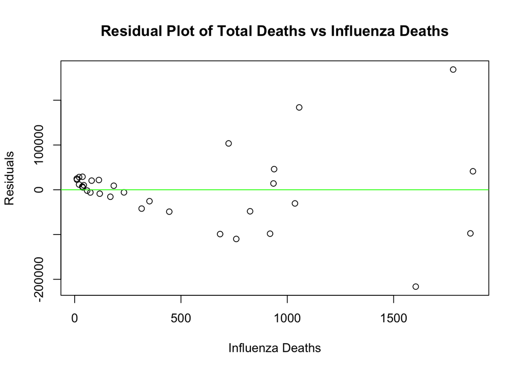

```r
#Residual plot for Total Deaths vs Influenza
plot(Influenza,L_Influenza$residuals,xlab="Influenza Deaths",ylab ="Residuals",main="Residual Plot of Total Deaths vs Influenza Deaths")
abline(h= 0,col="green")
```

### 2.3.4 Vertical Strips

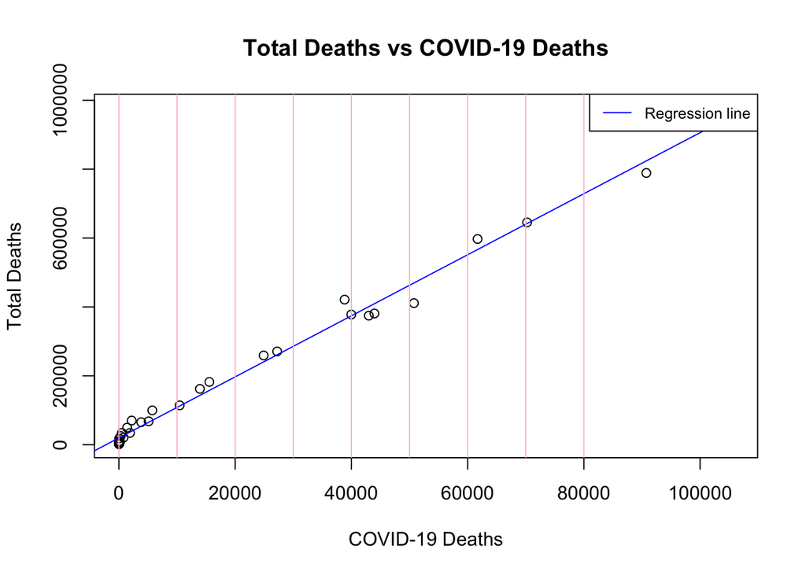

```r
##A regression line on the scatter plot for Total Deaths vs COVID 19
L_COVID_19 = lm(Total_Deaths~COVID_19)
plot(COVID_19,Total_Deaths,
     main = "Total Deaths vs COVID-19 Deaths",
     xlab = "COVID-19 Deaths",
     ylab = "Total Deaths")
abline(L_COVID_19,col="blue")
legend("topright",c("Regression line"),col ="blue",lty=1:2,cex=0.8)

##Vertical Strips
abline(v=c(0,10000,20000,30000,40000,50000,60000,70000,80000), col=c("pink"))
```

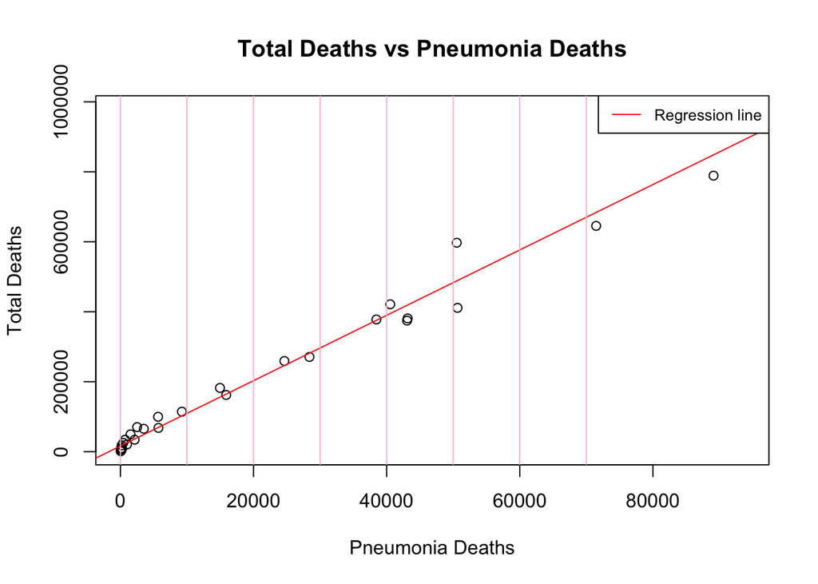

```r
#A regression line on the scatter plot for Total Deaths vs Pneumonia
L_Pneumonia = lm(Total_Deaths~Pneumonia)
plot(Pneumonia,Total_Deaths,
     main = "Total Deaths vs Pneumonia Deaths",
     xlab = "Pneumonia Deaths",
     ylab = "Total Deaths")
abline(lm(Total_Deaths~Pneumonia),col="red")
legend("topright",c("Regression line"),col="red",lty=1:2,cex=0.8)

##Vertical Strips
abline(v=c(0,10000,20000,30000,40000,50000,60000,70000), col=c("pink"))
```

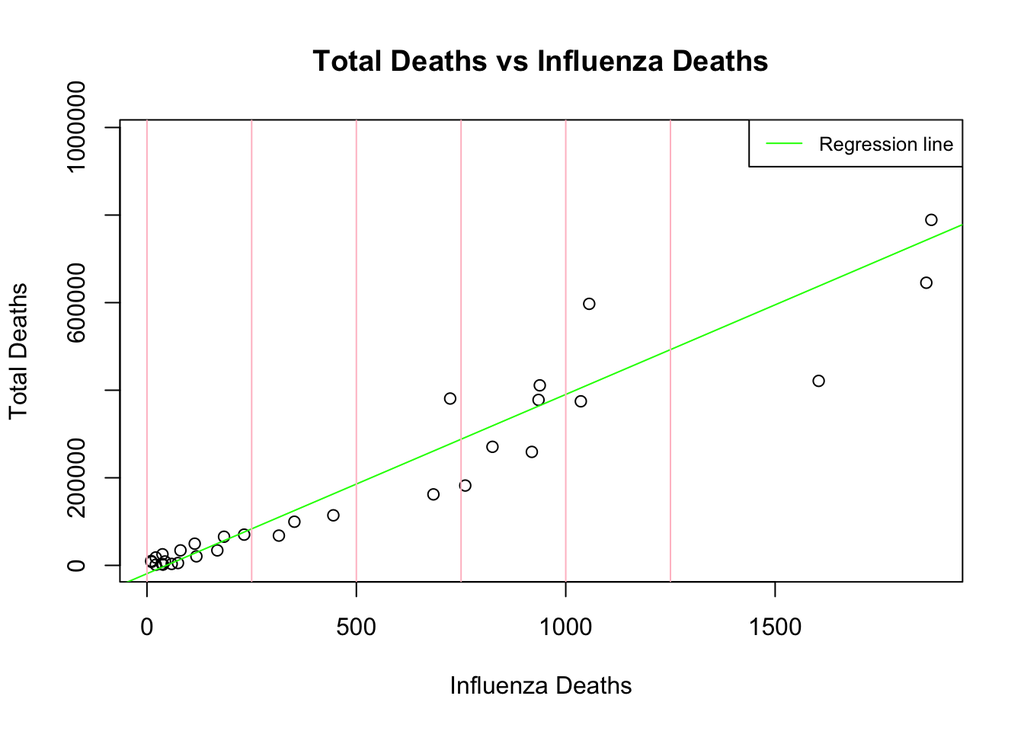

```r
#A regression line on the scatter plot for Total Deaths vs Influenza
L_Influenza = lm(Total_Deaths~Influenza)
plot(Influenza,Total_Deaths,
     main = "Total Deaths vs Influenza Deaths",
     xlab = "Influenza Deaths",
     ylab = "Total Deaths")
abline(lm(Total_Deaths~Influenza),col="green")
legend("topright", c("Regression line"),col="green",lty=1:2,cex=0.8)

##Vertical Strips
abline(v=c(0,250,500,750,1000,1250), col=c("pink"))
```

### 2.3.5 Analysis

#### 2.3.5.1 Correlation:

The correlation coefficient of 1 for Total Deaths vs COVID-19 Deaths, 1 for Total Deaths vs Pneumonia Deaths, and 0.9 for Total Deaths vs Influenza Deaths indicate strong positive relationships.

#### 2.3.5.2 Regression Line:

- y = 19764.608100 + 8.862942x indicates if COVID-19 Deaths increase by 1 death, Total Deaths increase by 8.86 deaths (2dp).
- y = 16069.767672 + 9.345382x indicates if Pneumonia Deaths increase by 1 death, Total Deaths increase by 9.35 deaths (2dp).
- y = -18913.1180 + 409.3284x indicates if Influenza deaths increase by 1 death, Total Deaths increase by 409.33 deaths (2dp).

#### 2.3.5.3 Scatter Plot:

The scatter plot shapes for all three pairs display strong positive relationships between the two variables in each pair.

#### 2.3.5.5 Vertical Strips:

The unequal spread of points across the vertical strips on the scatter plots and the fanning out of points on the residual plots reveal that the data is heteroscedastic for all three relationships, indicating that the regression lines should not be used for predictions.

### 2.3.6 Summary

The strong positive linear relationships between Total Deaths vs COVID-19, Pneumonia, and Influenza Deaths can be attributed to the fact that COVID-19, Pneumonia, and Influenza death count numbers contribute to Total Death count numbers – as the illness death counts increase, the total death counts increase.

The heteroscedasticity of the plots indicate that it is inappropriate to use these relationships to make predictions about the illnesses impact on the rate of total deaths as using extrapolation to make predictions for values that are not within our range of data can be unreliable as it is impossible to know whether the long-term trend will remain linear.

The slope and intercepts of the regression lines reveal that COVID-19 and Pneumonia have a similar impact on the total death count, which can be attributed to the fact that both illnesses have similar symptoms and complications, and Pneumonia can be a complication of COVID-19.

COVID-19 showed the highest impact on total deaths (for every COVID-19 death, there is 8.86 other deaths) closely followed by Pneumonia (for every Pneumonia death, there is 9.35 other deaths). Influenza showed the lowest impact (for every Influenza death, there is 409.33 other deaths), which can be attributed to the effective employment of the Influenza vaccine.

# 3 Contribution statement

**490185362:**  
IDA variables  
Research Question 1  
Research Question 2

**500483091:**  
IDA variables  
IDA source  
Research Question 1

**450192993:**  
Executive summary  
IDA source  
Research Question 2

# 4 References

National Centre for Health Statistics. (2021). Provisional COVID-19 Deaths Counts by Sex, Age, and State [Dataset]. https://data.cdc.gov/NCHS/Provisional-COVID-19-Death-Counts-by-Sex-Age-and-S/9bhg-hcku